{% raw %}

{% endraw %} {% raw %}

{% endraw %}

## Challenge 1: Define the experiment.

First we define how the experiment works. Here, we will simulate a two-armed bandit experiment. In the two-armed bandit task participants repeatedly choose between two stimuli. Each stimulus has a certain **reward probability**. Participants complete several **trials** and their goal is to maximize **rewards**.

### Step 1: Define the number of trials and reward probabilities.

First, we have to decide on the number of trials and the reward probabilities for each stimulus. Store the number of trials in a variable `T` and store the reward probabilities (one for each of the two stimuli) in variable `mu`. {% include note.html content='You can define these parameters however you want. In the Collins paper there were 100 trials and the reward probabilities were .2 for one stimulus and .8 for the other.' %}

*Enter your code here:*

*Check the solution below:*

{% raw %}

```python
T = 100
mu = [.2, .8]
```

{% endraw %}

### Step 2: Write the reward function.

The reward function allocates reward stochastically based on reward probabilities. This function uses an action and the reward probabilities as inputs and returns either a reward of 1 or no reward (0).

It achieves this by generating a random number from a uniform distribution ranging from 0 and 1 (in Python you can do this using `np.random.random()`).

*Enter your code here:*

*Check the solution below:*

{% raw %}

```python
def allocate_reward(action, mu):
    if np.random.random() < mu[action]:
        return 1
    else:
        return 0
```

{% endraw %}

## Challenge 2: Set up your first behavioral model (Rescorla-Wagner).

The Rescorla-Wagner model consists of a softmax choice rule and a Q-learning update algorithm. Initially, the model does not know which action is the best choice, so both actions should have the same Q-value.

### Step 1: Initialize your Q-values

In this step you define the initial Q-values. Store them in a variable `Q`.

{% include note.html content='We will need to run some calculations with these Q-values. To allow for this you’ll have to place your Q-values into a numpy array `np.array([...,...])`. The initial values should not matter much, but Collins et al. set them to .5.' %}

*Enter your code here:*

*Check the solution below:*

{% raw %}

```python
Q = np.array([0.5, 0.5])
```

{% endraw %}

### Step 2: Implement the softmax function.

The softmax function determines **choice probabilities** based on Q-values using the following formula:

$p_a = \dfrac{exp(Q_{at}*beta)} {\Sigma{exp(Q_{at}*beta)}}$

As you can see, this function also introduces our first participant parameter the **inverse temperature (beta)**. The larger beta the more deterministic (less random) a person's choices are.

> Bonus Question:What else does this function do, next to introducing beta?

#### 2.2 Define beta

First define beta and store it in the variable `beta`. Here you can pick any positive value (we chose 4).

> Bonus Question:Why does beta need to be positive?

*Enter your code here:*

*Check the solution below:*

{% raw %}

```python
beta = 4
```

{% endraw %}

#### 2.3 Implement the softmax function.

> Note, remember in python you implement functions by writing:

> ```
> def softmax(Q, beta): # Q and beta are your inputs
>     ...
>     return p # p is your return value
> ```

> To exponentiate an array you use `np.exp()` and to calculate the sum of an array, you use `np.sum()`.

*Enter your code here:*

*Check the solution below:*

{% raw %}

```python
def softmax(Q, beta):
    p = np.exp(Q*beta) / sum(np.exp(Q*beta))
    return p
```

{% endraw %}

### Step 3: Write a decision function.

This function uses choice probabilities as an input and returns a concrete choice as an output. It achieves this by first generating a random number from a uniform distribution ranging from 0 and 1 (in Python you can do this using `np.random.random()`).

Next, it compares the first choice probability to this number. If it is lower or equal to the choice probability the chosen action is 0, else the chosen action is 1.

{% include note.html content='Call this function `choose()`. You will need an if statement. Remember, in Python, you define this as:' %}

```
if ...:
    ...
else:
    ...
```

*Enter your code here:*

*Check the solution below:*

{% raw %}

```python
def choose(p):
    random_number = np.random.random()
    if random_number <= p[0]:
        return 0
    else:
        return 1
```

{% endraw %}

### Step 4: Write the update function

The update function updates Q-values based on the reward, according to this formula: $Q_{a,t+1} = Q_{a,t} + \alpha (r - Q_{a,t})$

As you can see, this function introduces another participant parameter: the **learning rate (alpha)**.

#### 4.1 Define alpha

Pick a value between 0 and 1 (we chose .2) and store it as `alpha`.

*Enter your code here:*

*Check the solution below:*

{% raw %}

```python
alpha = .2
```

{% endraw %}

#### 4.2: Write the update function

*Enter your code here:*

*Check the solution below:*

{% raw %}

```python
def update_q(Q, action, reward, alpha):
    delta = reward - Q[action] # prediction error
    Q[action] = Q[action] + alpha * delta
    return Q, delta
```

{% endraw %}

### Step 5: Putting it all together

Congratulations, you created all the components of your simulation function. Now let's put them all together and simulate some data. The simulation function (call it `simulate_M3RescorlaWagner_v1`) takes the experiment parameters, `mu` and `T`, as well as the participant parameters `alpha` and `beta` as inputs. {% include note.html content='Don’t forget to initialize the q-values as we did in step 2.1.' %} In each trial, we simulate an action chosen by the participant, allocate a reward, and update the participant's q-values accordingly. {% include note.html content='In Python you write loops like this:' %}

```
for t in range(T):
    ...
```

As outputs it returns the lists (i.e., vectors) `actions`, `rewards`, `Qs`, and `deltas` for each trial. {% include note.html content='You create vectors like this `actions = []` and add data to a vector like this: `actions.append(action)`.' %}{% include warning.html content='For technical reasons, when you append Q to Qs, you have to append a copy of Q with `Qs.append(Q.copy())`' %}

*Enter your code here:*

*Check the solution below:*

{% raw %}

```python
def simulate_M3RescorlaWagner_v1(T, mu, alpha, beta):
    Qs = []
    deltas = []
    actions = []
    rewards = []

    Q = np.array([.5, .5])

    for t in range(T):
        Qs.append(Q.copy())
        p = softmax(Q, beta)
        action = choose(p)
        reward = allocate_reward(action, mu)
        Q, delta = update_q(Q, action, reward, alpha)
        rewards.append(reward)
        actions.append(action)
        deltas.append(delta)

    return actions, rewards, Qs, deltas
```

{% endraw %}

## Challenge 3: Explore the parameters

We already wrote you a little function that simply uses your `simulate_M3RescorlaWagner_v1` function to simulate an experiment based on your parameters and plots its outputs in a figure. Below, we will go through some parameter combinations and explore their effects.

{% raw %}

```python
%matplotlib inline
%config InlineBackend.figure_format = 'retina'
```

{% endraw %} {% raw %}

`plot_rescorla_game`[[source]](https://github.com/hgzech/simulation_workshop/tree/master/simulation_workshop/interactive_session.py#L13)

> `plot_rescorla_game`(**`T`**, **`mu`**, **`alpha`**, **`beta`**)

{% endraw %} {% raw %}

{% endraw %}

Here are some example parameter values:

{% raw %}

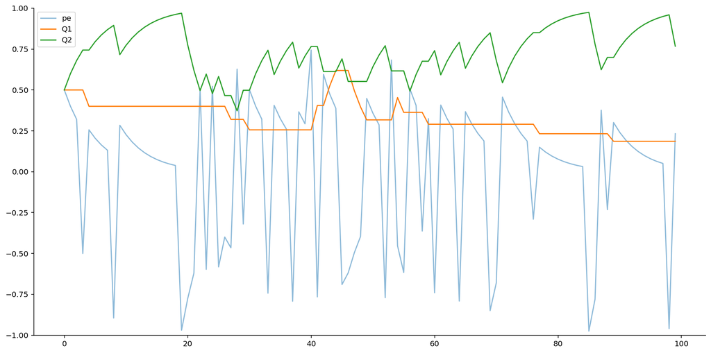

```python
T = 100 # number of trials
mu = [.2,.8] # reward probabilities
alpha = .2 # learning rate
beta = 4 # inverse temperature
plot_rescorla_game(T, mu, alpha, beta)
```

{% endraw %}

> Reducing the learning rate (participant does not manage to learn probabilities)

{% raw %}

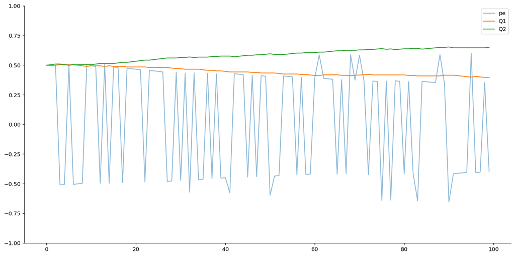

```python
T = 100 # number of trials
mu = [.2,.8] # reward probabilities
alpha = .01 # learning rate
beta = 4 # inverse temperature
plot_rescorla_game(T, mu, alpha, beta)
```

{% endraw %}

> Let's give them more trials

{% raw %}

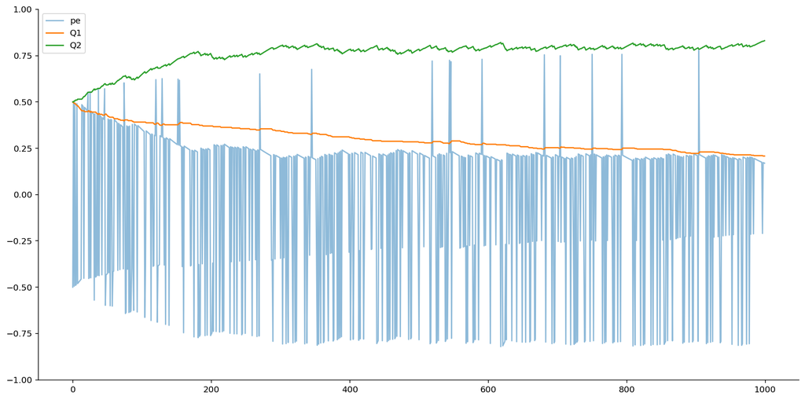

```python
T = 1000 # number of trials
mu = [.2,.8] # reward probabilities
alpha = .01 # learning rate
beta = 4 # inverse temperature
plot_rescorla_game(T, mu, alpha, beta)
```

{% endraw %}

> An extreme beta value makes participants stop exploring.

{% raw %}

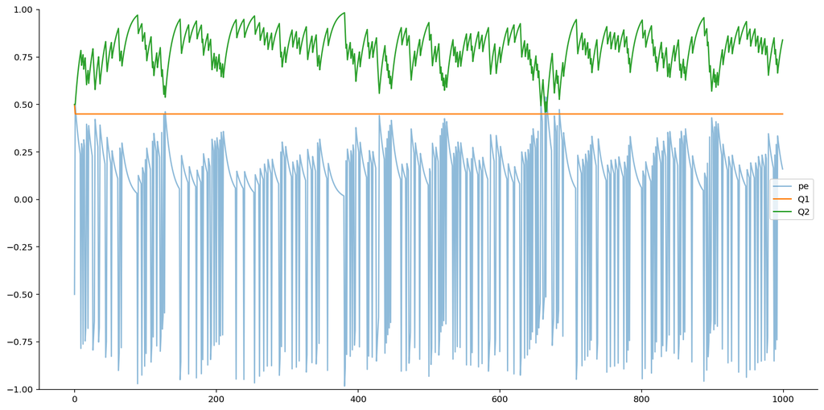

```python
T = 1000 # number of trials
mu = [.2,.8] # reward probabilities
alpha = .1 # learning rate
beta = 1000 # inverse temperature
plot_rescorla_game(T, mu, alpha, beta)
```

{% endraw %}

> If beta is very low, participants still learn, but they don't use that knowledge (something that we cannot see in this plot yet).

{% raw %}

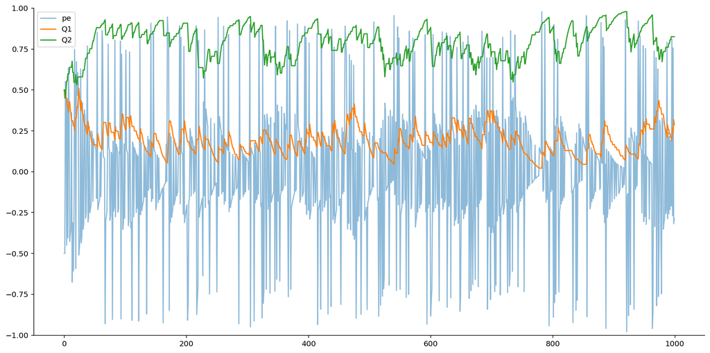

```python
T = 1000 # number of trials
mu = [.2,.8] # reward probabilities
alpha = .1 # learning rate
beta = .0000000001 # inverse temperature
plot_rescorla_game(T, mu, alpha, beta)
```

{% endraw %}

## Challenge 4: Choice Kernel

The only difference between choice kernel and rescorla-wagner is that the softmax function takes choice_kernel values instead of Q-values as inputs and the update function is indendent of rewards. Therefore, we only need to change the update function.

### Step 1: Write a new update function

The formula of the update function looks like this:

$CK_{a,t+1} = CK_{a,t} + \alpha * 1$

Before the choice kernel is updated, both choice kernels decay with the inverse of the learning rate:

$CK_{t+1} = CK_{t} * (1 - \alpha) $

Call this function `update_choice_kernels`, with the inputs `choice_kernel`, `action`, and `alpha`. {% include note.html content='If you’re confused by the multiplication with one: This is only for comparability with the Rescorla-Wagner.' %}

*Enter your code here:*

*Check the solution below:*

{% raw %}

```python
def update_choice_kernels(choice_kernel, action, alpha):
    choice_kernel = (1 - alpha) * choice_kernel
    choice_kernel[action] = choice_kernel[action] + alpha * 1
    return choice_kernel
```

{% endraw %}

### Step 2: Putting it all together.

Now make a `simulate_M4ChoiceKernel_v1` function similar to the rescorla wagner function but with our new update function and choice kernels instead of Qs.

*Enter your code here:*

*Check the solution below:*

{% raw %}

`simulate_M4ChoiceKernel_v1`[[source]](https://github.com/hgzech/simulation_workshop/tree/master/simulation_workshop/interactive_session.py#L27)

> `simulate_M4ChoiceKernel_v1`(**`T`**, **`mu`**, **`alpha`**, **`beta`**)

{% endraw %} {% raw %}

{% endraw %}

> Note that choice_kernel decays with the inverted alpha in each trial `choice_kernel = (1 - alpha_c) * choice_kernel`

## Challenge 5: Explore the parameters of your choice kernel simulations

{% raw %}

`plot_choice_kernel_game`[[source]](https://github.com/hgzech/simulation_workshop/tree/master/simulation_workshop/interactive_session.py#L47)

> `plot_choice_kernel_game`(**`T`**, **`mu`**, **`alpha`**, **`beta`**)

{% endraw %} {% raw %}

{% endraw %} {% raw %}

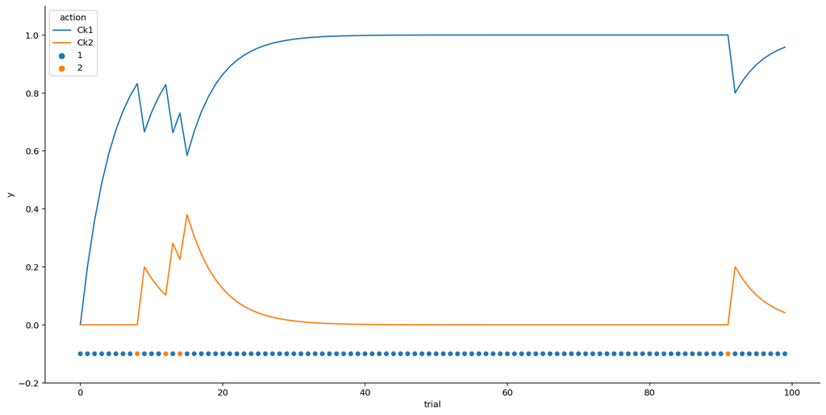

```python
T = 100 # number of trials
mu = [.2,.8] # reward probabilities
alpha = .2 # learning rate
beta = 4 # inverse temperature
actions = plot_choice_kernel_game(T, mu, alpha, beta)
```

{% endraw %} {% raw %}

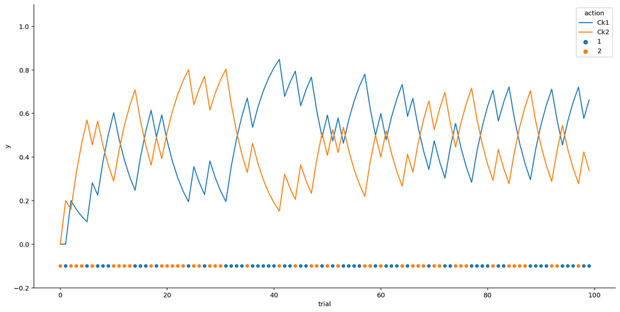

```python
T = 100 # number of trials
mu = [.2,.8] # reward probabilities
alpha = .2 # learning rate
beta = .004 # inverse temperature
actions = plot_choice_kernel_game(T, mu, alpha, beta)
```

{% endraw %} {% raw %}

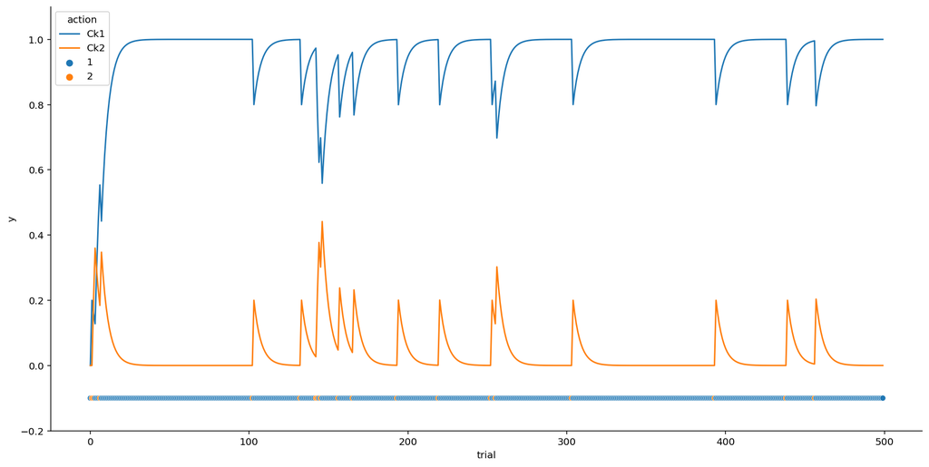

```python
T = 500 # number of trials
mu = [.2,.8] # reward probabilities
alpha = .2 # learning rate
beta = 4 # inverse temperature
actions = plot_choice_kernel_game(T, mu, alpha, beta)
```

{% endraw %}

> With a reasonably high beta one of the options should always move towards 1.